# Lab I: Dynamic Inventory Planning

Zifeng Zhao

week 02 session 02

In this lab, we will build a linear regression-based dynamic inventory planning system for a German retail chain.

## 1. Read in data and data wrangling

Let’s read in the data from `Bakery_sales_data.csv` and further conduct some data manipulation.

```r
total_data <- read.csv("./Bakery_sales_data.csv", header=T, stringsAsFactors=T)
str(total_data)
```

```
## 'data.frame':    18260 obs. of  9 variables:
##  $ date       : Factor w/ 1826 levels "1/1/2013","1/1/2014",..: 1 56 111 126 131 136 141 146 151 6 ...
##  $ store_id   : int  1 1 1 1 1 1 1 1 1 1 ...
##  $ item_id    : int  1032943 1032943 1032943 1032943 1032943 1032943 1032943 1032943 1032943 1032943 ...
##  $ sales      : int  242 152 172 221 247 248 222 149 214 307 ...
##  $ store_type : Factor w/ 3 levels "rural","suburb",..: 3 3 3 3 3 3 3 3 3 3 ...
##  $ bad_weather: int  1 0 0 0 0 0 0 1 0 0 ...
##  $ promotion  : num  0 0 0 0 0 0 0 0 0.05 0 ...
##  $ day        : Factor w/ 7 levels "Friday","Monday",..: 6 7 5 1 3 4 2 6 7 5 ...
##  $ month      : Factor w/ 12 levels "April","August",..: 5 5 5 5 5 5 5 5 5 5 ...
```

We first reset the format of the `date` variable in `total_data` using `as.Date` function.

```r
total_data$date <- as.Date(total_data$date, format="%m/%d/%Y")
str(total_data)
```

```
## 'data.frame':    18260 obs. of  9 variables:
##  $ date       : Date, format: "2013-01-01" "2013-01-02" ...
##  $ store_id   : int  1 1 1 1 1 1 1 1 1 1 ...
##  $ item_id    : int  1032943 1032943 1032943 1032943 1032943 1032943 1032943 1032943 1032943 1032943 ...
##  $ sales      : int  242 152 172 221 247 248 222 149 214 307 ...
##  $ store_type : Factor w/ 3 levels "rural","suburb",..: 3 3 3 3 3 3 3 3 3 3 ...
##  $ bad_weather: int  1 0 0 0 0 0 0 1 0 0 ...
##  $ promotion  : num  0 0 0 0 0 0 0 0 0.05 0 ...
##  $ day        : Factor w/ 7 levels "Friday","Monday",..: 6 7 5 1 3 4 2 6 7 5 ...
##  $ month      : Factor w/ 12 levels "April","August",..: 5 5 5 5 5 5 5 5 5 5 ...
```

Let’s reset the reference level of the categorical variables in the data set using the `R` function `factor()` and its argument `levels`. In addition, note that the `store_id` variable in `total_data` should be categorical variable as it is an identifier of each store.

```r
total_data$day <- factor(total_data$day, levels=c('Monday','Tuesday','Wednesday','Thursday','Friday','Saturday','Sunday'))
total_data$month <- factor(total_data$month, levels=c('January','February','March','April','May','June','July',
                                                      'August','September','October','November','December'))
total_data$store_type <- factor(total_data$store_type, levels=c('rural','suburb','urban'))
total_data$store_id <- factor(total_data$store_id)
```

### 1.1 Data exploration and visualization

**Exercise 1** Create a scatter plot between `sales` and `promotion`. Note that `promotion` is a numerical predictor but only takes a finite number of values. Thus, let’s further make a boxplot between `sales` and `promotion`, which is more informative.

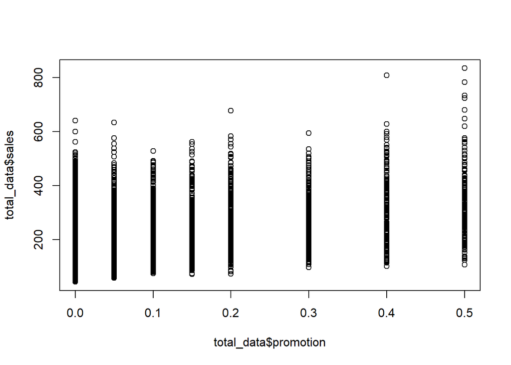

```r
# Exercise 1 code
plot(total_data$promotion, total_data$sales)
```

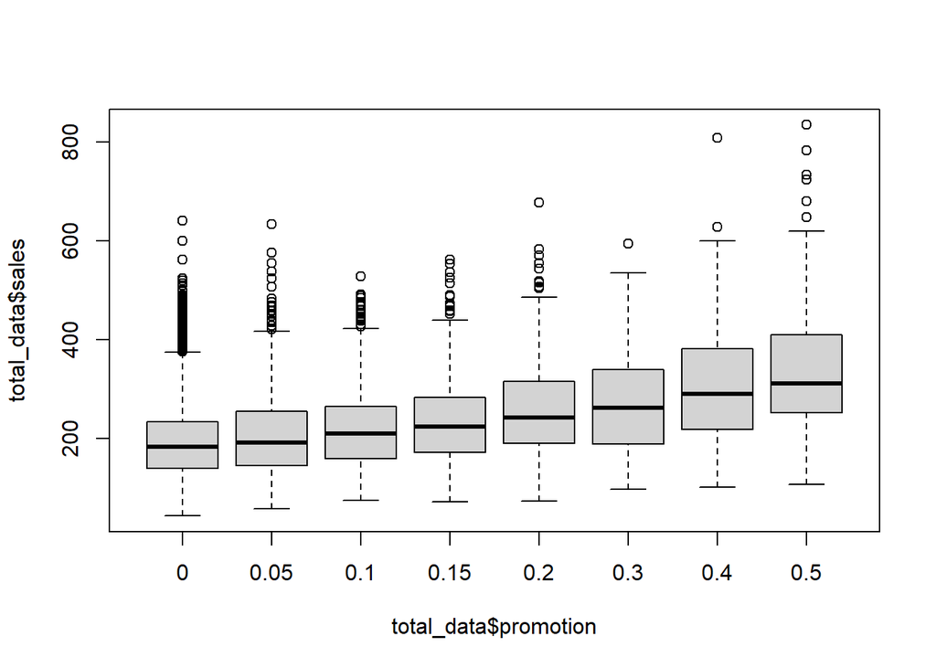

```r
boxplot(total_data$sales ~ total_data$promotion)
```

**Exercise 2** Create a boxplot between `sales` and `store type`. Which type of store has the highest sales on average?

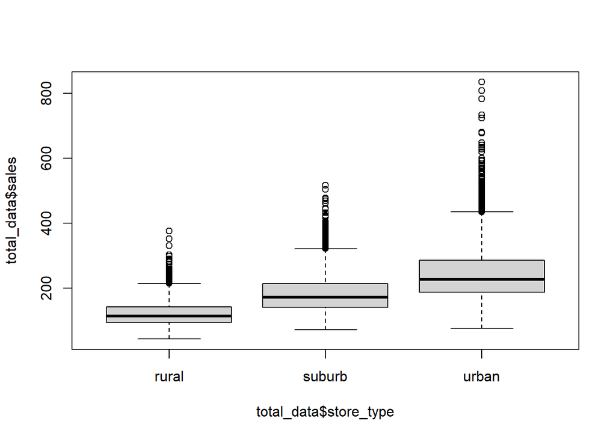

```r
# Exercise 2 code
boxplot(total_data$sales ~ total_data$store_type)
```

Store in the urban area have a higher sales **Exercise 3** Use appropriate visualization tools to investigate the relationship between `sales` and `bad_weather`, `sales` and `day`, `sales` and `month`.

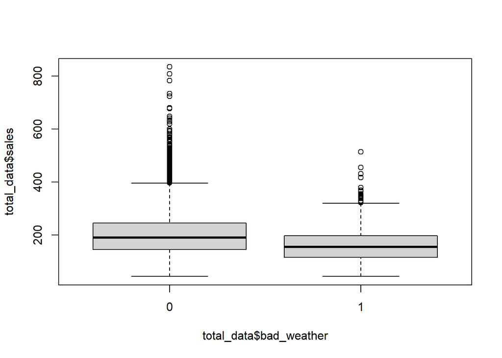

```r
# Exercise 3 code

boxplot(total_data$sales ~ total_data$bad_weather)
```

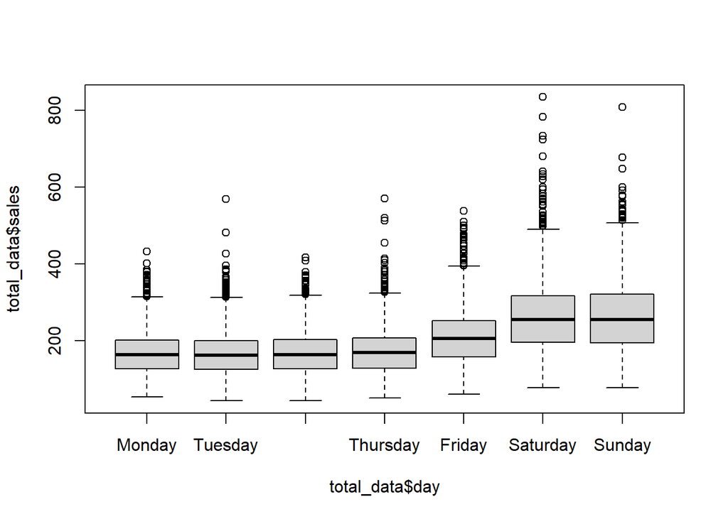

```r
boxplot(total_data$sales ~ total_data$day)
```

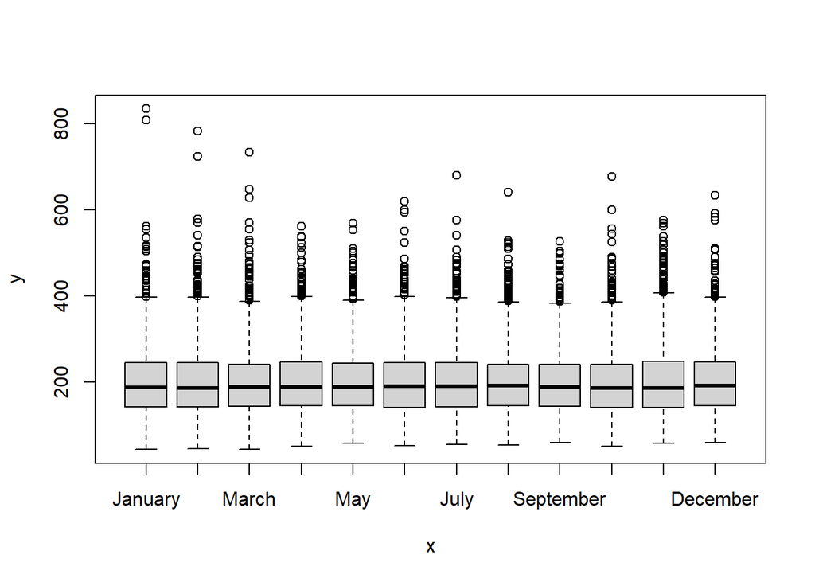

```r
plot(total_data$month, total_data$sales)
```

**Exercise 4** Plot the histogram of `sales`. Do we need a log transformation? If so, further create a `log_sales` variable in the `R` object `total_data` using the formula $\widetilde{Y}=\log(Y+1).$

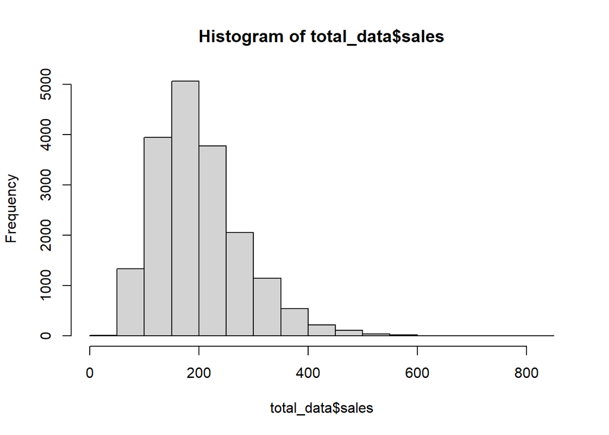

```r
# Exercise 4 code
hist(total_data$sales)
```

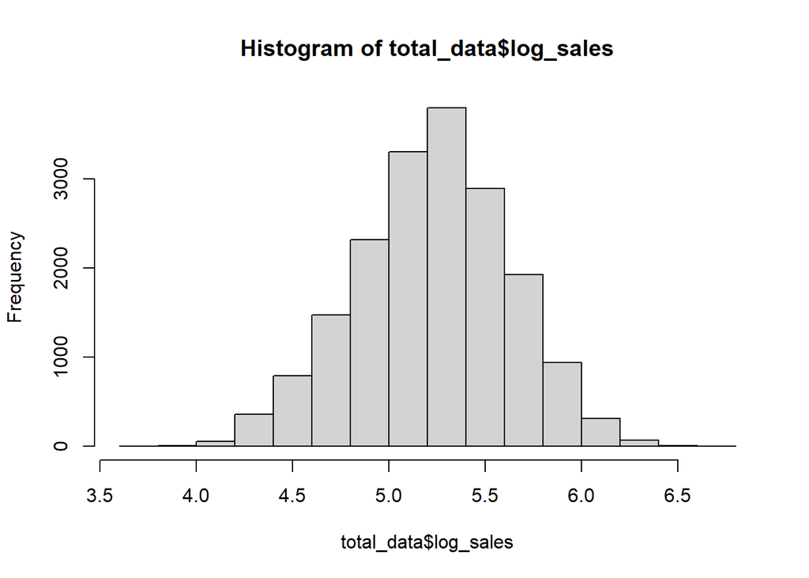

```r
total_data$log_sales <- log(total_data$sales + 1)
hist(total_data$log_sales)
```

base on our graph, sales is right skewed and log_sale can fix it

## 2. Linear Regression based forecasting

### 2.1 Data partition

Note that for time series forecasting, data partition should respect the time order as we would like to evaluate the performance of statistical models on the most recent data.

```r
train_indices <- which(total_data$date<='2016-12-31') # We create 4 year training data and leave 1 year for test
train_data <- total_data[train_indices,]
test_data <- total_data[-train_indices,]
```

### 2.2 Linear regression estimation

**Exercise 5** Estimate a linear regression model with only intercept and name it `lm0`. Estimate a linear regression model with **five** predictors `store_type`, `bad_weather`, `promotion`, `day` and `month` and name it `lm_full`. Note the dependent variable should be `log_sales`.

```r
# Exercise 5 code
lm0 <- lm(log_sales~1, train_data)
lm_full <- lm(log_sales~store_type+bad_weather+promotion+day+month, train_data)
summary(lm_full)
```

```
##
## Call:
## lm(formula = log_sales ~ store_type + bad_weather + promotion +
##     day + month, data = train_data)
##
## Residuals:
##      Min       1Q   Median       3Q      Max
## -0.78639 -0.13441 -0.00033  0.13478  0.74390
##
## Coefficients:
##                    Estimate Std. Error t value Pr(>|t|)
## (Intercept)       4.5800323  0.0077945 587.599  < 2e-16 ***
## store_typesuburb  0.4064093  0.0047774  85.070  < 2e-16 ***
## store_typeurban   0.6911623  0.0043785 157.853  < 2e-16 ***
## bad_weather      -0.2219231  0.0074461 -29.804  < 2e-16 ***
## promotion         1.1822489  0.0208007  56.837  < 2e-16 ***
## dayTuesday       -0.0094510  0.0061963  -1.525    0.127
## dayWednesday      0.0012979  0.0061966   0.209    0.834
## dayThursday       0.0265175  0.0061966   4.279 1.89e-05 ***
## dayFriday         0.2250730  0.0061971  36.319  < 2e-16 ***
## daySaturday       0.4472634  0.0061965  72.180  < 2e-16 ***
## daySunday         0.4426998  0.0062034  71.364  < 2e-16 ***
## monthFebruary    -0.0033872  0.0082278  -0.412    0.681
## monthMarch       -0.0099513  0.0080360  -1.238    0.216
## monthApril       -0.0055977  0.0081013  -0.691    0.490
## monthMay         -0.0068026  0.0080341  -0.847    0.397
## monthJune        -0.0097249  0.0081018  -1.200    0.230
## monthJuly        -0.0039633  0.0080343  -0.493    0.622
## monthAugust       0.0006729  0.0080350   0.084    0.933
## monthSeptember   -0.0010249  0.0081019  -0.126    0.899
## monthOctober     -0.0115482  0.0080340  -1.437    0.151
## monthNovember    -0.0121541  0.0081013  -1.500    0.134
## monthDecember     0.0021061  0.0080349   0.262    0.793
## ---
## Signif. codes:  0 '***' 0.001 '**' 0.01 '*' 0.05 '.' 0.1 ' ' 1
##
## Residual standard error: 0.2 on 14588 degrees of freedom
## Multiple R-squared:  0.7488, Adjusted R-squared:  0.7485
## F-statistic:  2071 on 21 and 14588 DF,  p-value: < 2.2e-16
```

```r
exp(-0.2219231)-1
```

```
## [1] -0.199023
```

```r
TSS <- sum((train_data$log_sales-mean(train_data$log_sales))^2)
RSS <- sum((train_data$log_sales-lm0$fitted.values)^2)
1-(RSS/TSS)
```

```
## [1] 7.771561e-16
```

**Exercise 6** What is the $R^2$ of `lm_full`? What is the impact of `bad_weather` to `log_sales` and thus to `sales`? What is the $R^2$ of `lm0`? Why? Answer: R^2 for the lm_full is 0.7488, bad weather have a significant impact to the log_sales so is the sales, if their is bad weather, the sale will drop around 20 percent R^2 for the lm0 is 7.771561e-16

### 2.2.1 Backward selection

**Exercise 7** It seems that some of the predictors are not statistically significant. First, determine the number of observations in the training data. Second, let’s do a backward selection via BIC using the `step()` function and store the final selected model as `lm_bwd`. Make sure you use the **correct** number for the argument `k` in the `step()` function.

```r
# Exercise 7 code
lm_bwd <- step(lm_full, k = log(length(train_indices)), direction = "backward")
```

```
## Start:  AIC=-46834.13
## log_sales ~ store_type + bad_weather + promotion + day + month
##
##               Df Sum of Sq     RSS    AIC
## - month       11      0.33  584.04 -46931
## <none>                      583.71 -46834
## - bad_weather  1     35.54  619.25 -45980
## - promotion    1    129.26  712.97 -43921
## - day          6    550.34 1134.05 -37188
## - store_type   2   1020.39 1604.10 -32084
##
## Step:  AIC=-46931.28
## log_sales ~ store_type + bad_weather + promotion + day
##
##               Df Sum of Sq     RSS    AIC
## <none>                      584.04 -46931
## - bad_weather  1     35.54  619.59 -46078
## - promotion    1    129.33  713.37 -44018
## - day          6    550.38 1134.42 -37289
## - store_type   2   1020.39 1604.43 -32186
```

```r
summary(lm_bwd)$r.sq
```

```
## [1] 0.7487004
```

**Exercise 8** What is the $R^2$ of `lm_bwd`? Which variable is removed during the backward selection? 0.7487004

### 2.3 Model evaluation (out-of-sample)

Let’s now evaluate the prediction performance of the three linear models `lm0`, `lm_full` and `lm_bwd` on the test data. First, let’s generate the prediction by each model and store them in `pred0`, `pred_full` and `pred_bwd` respectively. Make sure to transform the prediction back to the **original** scale. We then use the `accuracy()` function from the `forecast` package to obtain the error metrics.

```r
# prediction of lm0
pred0 <- exp(predict(lm0, test_data))-1

# prediction of full model
pred_full <- exp(predict(lm_full, test_data))-1

# prediction of backward selected model
pred_bwd <- exp(predict(lm_bwd, test_data))-1

library(forecast)
# error of lm0
accuracy(pred0, test_data$sales)
```

```
##                ME    RMSE      MAE      MPE     MAPE
## Test set 16.63424 84.3036 62.31871 -7.65286 33.59041
```

```r
# error of full model
accuracy(pred_full, test_data$sales)
```

```
##                ME     RMSE      MAE       MPE     MAPE
## Test set 5.914172 44.74435 32.60355 -1.220831 16.23773
```

```r
# error of backward selected model
accuracy(pred_bwd, test_data$sales)
```

```
##                ME     RMSE      MAE       MPE     MAPE
## Test set 5.924055 44.74182 32.59904 -1.220761 16.23744
```

**Exercise 9** Which model should we choose and why? Judging by its performance on the test data, do you think the prediction given by linear regression is reasonably accurate? We should choose lm_bwd since it has the lowest MAE, and due number of variable, lm_bwd is a relatively simpler model compare with lm_full, the prediction is reasonably accurate, our MAPE is only 16.24 percent

### 2.3.1 Visualization of the prediction on test data

**Exercise 10** To gain more intuition, let’s visualize the prediction given by the linear regression `lm_bwd` on the test data and compare it with the actual observations. Specifically, let’s visualize the result for the first 60 days in the test data.

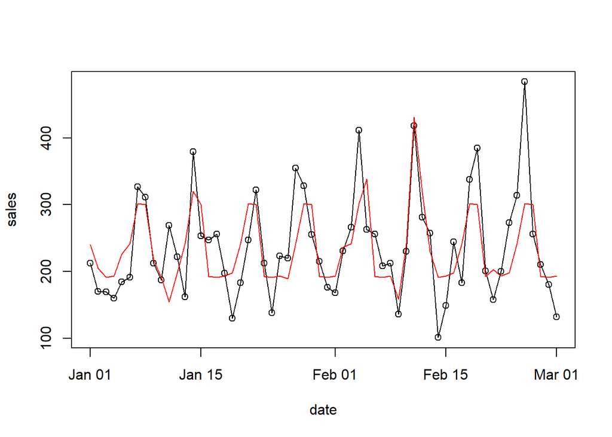

```r
# Exercise 10
sample_time <- 1:60
plot(test_data$date[sample_time], test_data$sales[sample_time], xlab='date', ylab='sales')
lines(test_data$date[sample_time], test_data$sales[sample_time], col = "black")
lines(test_data$date[sample_time], pred_bwd[sample_time], col = "red")
```

## 3. In class exercise (Optional)

Rerun the above analysis with the original scale `sales`. Name the corresponding `R` objects as `lm_full1` and `lm_bwd1`. What is the test data error for `lm_full1` and `lm_bwd1`? Does log transformation help improve the forecasting accuracy?

```r
lm_full1 <- lm(sales~store_type+bad_weather+promotion+day+month, train_data)
lm_bwd1 <- step(lm_full1, k = log(length(train_indices)), direction = "backward")
```

```
## Start:  AIC=111246.2
## sales ~ store_type + bad_weather + promotion + day + month
##
##               Df Sum of Sq      RSS    AIC
## - month       11      7470 29199519 111144
## <none>                     29192049 111246
## - bad_weather  1   1149202 30341251 111801
## - promotion    1   7371995 36564044 114526
## - day          6  24614368 53806417 120123
## - store_type   2  33015878 62207927 122281
##
## Step:  AIC=111144.4
## sales ~ store_type + bad_weather + promotion + day
##
##               Df Sum of Sq      RSS    AIC
## <none>                     29199519 111144
## - bad_weather  1   1147002 30346521 111698
## - promotion    1   7375091 36574610 114425
## - day          6  24626085 53825604 120022
## - store_type   2  33015945 62215464 122177
```

```r
pred_full1 <- predict(lm_full1, test_data)
pred_bwd1 <- predict(lm_bwd1, test_data)
accuracy(pred_full1, test_data$sales)
```

```
##                ME     RMSE      MAE       MPE     MAPE
## Test set 1.852445 46.46293 34.56074 -2.916485 17.85364
```

```r
accuracy(pred_bwd1, test_data$sales)
```

```
##             ME     RMSE      MAE       MPE     MAPE
## Test set 1.852 46.46131 34.55487 -2.917064 17.85139
```

```r
accuracy(pred_full, test_data$sales)
```

```
##                ME     RMSE      MAE       MPE     MAPE
## Test set 5.914172 44.74435 32.60355 -1.220831 16.23773
```

```r
accuracy(pred_bwd, test_data$sales)
```

```
##                ME     RMSE      MAE       MPE     MAPE
## Test set 5.924055 44.74182 32.59904 -1.220761 16.23744
```

Yes, the log transformation help lower the MAE.

## 4. Inventory planning with asymmetric revenue and loss (Optional)

The ultimate goal for demand forecasting is to decide the optimal inventory level that maximizes the **profit**. Following the notation in the lecture notes.

**Exercise 11** Suppose $r=\$10, l=\$1$, what is the optimal inventory level? Answer: 0.9 quantile of the future sales.

```r
# This is a customized function to evaluate the profit we will receive on the test data
profit <- function(pred, actual, loss, revenue){
  profit <- revenue-loss
  tmp <- sum(profit*pred[pred<actual])+sum((profit*actual-loss*(pred-actual))[actual<=pred])
  return(tmp)
}
```

How do we generate the prediction of 90% quantile of future sales? We use **Prediction interval!** The function `predict()` in `R` can achieve that with the additional argument `interval='prediction'` and `level`. The `level` argument specifies the confidence level of the prediction interval. Note that the prediction interval is two-sided, thus, to obtain the $q$ quantile of the predicted sales, we need to set the `level` argument as `level`=$1-2(1-q)$. In our case, $q=0.9$.

```r
pred_interval_level <- 1-2*(1-0.9)
pred_opt <- exp(predict(lm_bwd, newdata=test_data, interval='prediction', level=pred_interval_level))-1
head(pred_opt)
```

```
##           fit      lwr      upr
## 1462 240.4904 185.8408 311.1245
## 1463 204.4502 157.9822 264.4999
## 1464 190.8441 147.4534 246.9171
## 1465 192.9111 149.0530 249.5883
## 1466 226.1215 174.7063 292.5819
## 1467 241.5470 186.6886 312.4397
```

Note that the `fit` column in `pred_opt` is the same as `pred_bwd`, which is the predicted mean of future sales given by the linear regression `lm_bwd`. The `upr` column in `pred_opt` gives the predicted 90% quantile of future sales. Let’s evaluate the achieved profit and the forecasting error of the predicted mean and predicted 90% quantile of future sales on the test data.

```r
# under stock probability in the test data
mean(pred_opt[,1]<test_data$sales)
```

```
## [1] 0.5172603
```

```r
mean(pred_opt[,3]<test_data$sales)
```

```
## [1] 0.1123288
```

```r
# Profit achieved in the test data
print(profit(pred=pred_opt[,1], actual=test_data$sales, loss=1, revenue=10))
```

```
## [1] 5952098
```

```r
print(profit(pred=pred_opt[,3], actual=test_data$sales, loss=1, revenue=10))
```

```
## [1] 6332106
```

```r
# Forecasting error achieved in the test data
print(accuracy(pred_opt[,1], test_data$sales))
```

```
##                ME     RMSE      MAE       MPE     MAPE
## Test set 5.924055 44.74182 32.59904 -1.220761 16.23744
```

```r
print(accuracy(pred_opt[,3], test_data$sales))
```

```
##                 ME     RMSE      MAE       MPE     MAPE
## Test set -51.66472 69.93919 57.84773 -30.97891 32.98428
```

**Exercise 12** Which prediction is more accurate? Which prediction is more profitable? Why is that?

We can further visualize the result to intuitively compare the predicted mean and predicted 90% quantile of future sales on the test data.

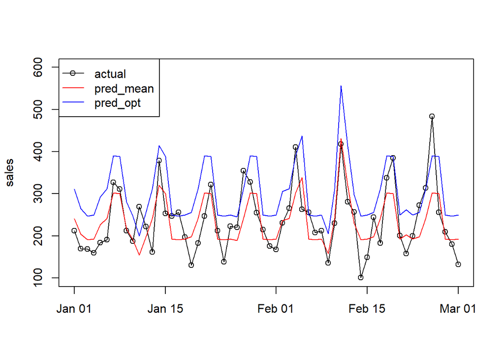

```r
# Manually configure the C.I.
sample_time <- 1:60
plot(test_data$date[sample_time], test_data$sales[sample_time], xlab='', ylab='sales', ylim=c(100,600))
lines(test_data$date[sample_time], test_data$sales[sample_time])
lines(test_data$date[sample_time], pred_opt[sample_time,1], col='red')
lines(test_data$date[sample_time], pred_opt[sample_time,3], col='blue')
legend('topleft', c('actual','pred_mean','pred_opt'), lty=c(1,1,1), col=c('black','red','blue'), pch=c(1,NA,NA))
```

the mean still predit better, but pred_opt result are more prepared since mean will give us a better MAE, but profit wise, the pred_opt is better.